# Evidencia 2 - Parte 2

Santiago Reyes Moran - A01639030

28/4/2021

## Parte 1 de la evidencia y referencias

```r
##Las referencias y el video las pongo primero para que no se pierdan en el documento
```

Video (Parte 1 de la evidencia): https://www.youtube.com/watch?v=eJFx7eqtzsM

Referencias: Rabaan, A. (n.d). EMERGENCIA DE SARS-COV-2. ASPECTOS BÁSICOS SOBRE SU ORIGEN, EPIDEMIOLOGÍA, ESTRUCTURA Y PATOGENIA PARA CLÍNICOS. PubMed Central (PMC). https://pubmed.ncbi.nlm.nih.gov/32275259/

Dabanch, J. (2021, 1 febrero). EMERGENCIA DE SARS-COV-2. ASPECTOS BÁSICOS SOBRE SU ORIGEN, EPIDEMIOLOGÍA, ESTRUCTURA Y PATOGENIA PARA CLÍNICOS. PubMed Central (PMC). https://www.ncbi.nlm.nih.gov/pmc/articles/PMC7849593/

Rao, Y. H. C. (2020, julio). The emergence of a novel coronavirus (SARS-CoV-2) disease and their neuroinvasive propensity may affect in COVID-19 patients. PubMed. https://pubmed.ncbi.nlm.nih.gov/32320066/

## Importación de librerias y de secuencias “limpias”

```r
library('seqinr')
```

```r
library('ggplot2')
library(ggthemes)
library(stringr)
#Ruta
getwd()
```

```
## [1] "C:/Users/user/Desktop/Biología computacional/Evidencia final"
```

```r
setwd("C:/Users/user/Desktop/Biología computacional/Evidencia final/FASTAS")

# Funcion de limpieza de caracteres: (Creditos a Lucas Wong)
clean <- function(x) {
  V1<-read.fasta(x)
  Vclean <- V1[[1]]
  Vclean <- Vclean[Vclean %in% c('a', 'c', 'g', 't')]
return(Vclean)
}

#Variantes de paises americanos
Var1<-clean('MT844047.fasta') #Guatemala - MT844047 - https://www.ncbi.nlm.nih.gov/nuccore/MT844047 - B.1
Var2<-clean('MT810698.fasta') #San Diego, California, Estados Unidos - MT810698 - https://www.ncbi.nlm.nih.gov/nuccore/MT810698 - B.1.241
Var3<-clean('MW553311.fasta') #Argentina - MW553311 - https://www.ncbi.nlm.nih.gov/nuccore/MW553311 - B.1
Var4<-clean('MW309435.fasta') #Canada - MW309435 - https://www.ncbi.nlm.nih.gov/nuccore/MW309435 - B.1.505

#Variantes de paises asiaticos
Var5<-clean('MT919768.fasta')#Filipinas  - MT919768 - https://www.ncbi.nlm.nih.gov/nuccore/MT919768 - B.6
Var6<-clean('MT879619.fasta')#Pakistan - MT879619 - https://www.ncbi.nlm.nih.gov/nuccore/MT879619 - B.1
Var7<-clean('MT847217.fasta') #Bangladesh - MT847217 -  https://www.ncbi.nlm.nih.gov/nuccore/MT847217 - B.1.1.25
Var8<-clean('MT781415.fasta') #Tailandia - MT781415 - https://www.ncbi.nlm.nih.gov/nuccore/MT781415 - A.6
Var9<-clean('MT372481.fasta') #Malasia - MT372481 - https://www.ncbi.nlm.nih.gov/nuccore/MT372481 - B.6.6

#Variantes de paises africanos
Var10<-clean('MT800035.fasta') #Egypto - MT800035 - https://www.ncbi.nlm.nih.gov/nuccore/MT800035 - B.1
Var11<-clean('MT801001.fasta') #Lebanon - MT801001 - https://www.ncbi.nlm.nih.gov/nuccore/MT801001 - B.1.1
Var12<-clean('MT801041.fasta') #Turquía - MT801041 - https://www.ncbi.nlm.nih.gov/nuccore/MT801041 - B.1.1
Var13<-clean('LR963411.fasta') #Zimbabwe - LR963411 - https://www.ncbi.nlm.nih.gov/nuccore/LR963411 - B.1.446
Var14<-clean('MW751197.fasta') #Kenya - MW751197 - https://www.ncbi.nlm.nih.gov/nuccore/MW751197 - B.1.535

#Variantes de paises europeos
Var15<-clean('OA975181.fasta') #Reino Unido - OA975181  - https://www.ncbi.nlm.nih.gov/nuccore/OA975181 - B.1.177
Var16<-clean('OA984027.fasta') #Escocia - OA984027 - https://www.ncbi.nlm.nih.gov/nuccore/OA984027 - AD.2
Var17<-clean('LR991977.fasta') #Polonia - LR991977 - https://www.ncbi.nlm.nih.gov/nuccore/LR991977 - B.1.1.219
Var18<-clean('LR883306.fasta') #Paises Bajos - LR883306 - https://www.ncbi.nlm.nih.gov/nuccore/LR883306 - L.2
Var19<-clean('MW423684.fasta') #Italia - MW423684 - https://www.ncbi.nlm.nih.gov/nuccore/MW423684 - B.1.258
Var20<-clean('MT459924.fasta') #Grecia - MT459924 - https://www.ncbi.nlm.nih.gov/nuccore/MT459924 - B.40

#Variante adicional de Oceania
Var21<-clean('MT973296.fasta') #Australia - MT973296 - https://www.ncbi.nlm.nih.gov/nuccore/MT973296 - A.2.2
```

## Longitud de cada variante

```r
#Longitud de las variantes de paises americanos
length(Var1) #Guatemala - MT844047 - https://www.ncbi.nlm.nih.gov/nuccore/MT844047 - B.1
```

```
## [1] 29882
```

```r
length(Var2) #San Diego, California, Estados Unidos - MT810698 - https://www.ncbi.nlm.nih.gov/nuccore/MT810698 - B.1.241
```

```
## [1] 29409
```

```r
length(Var3) #Argentina - MW553311 - https://www.ncbi.nlm.nih.gov/nuccore/MW553311 - B.1
```

```
## [1] 29726
```

```r
length(Var4) #Canada - MW309435 - https://www.ncbi.nlm.nih.gov/nuccore/MW309435 - B.1.505
```

```
## [1] 29314
```

```r
#Longitud de las variantes de paises asiaticos
length(Var5) #Filipinas  - MT919768 - https://www.ncbi.nlm.nih.gov/nuccore/MT919768 - B.6
```

```
## [1] 29813
```

```r
length(Var6) #Pakistan - MT879619 - https://www.ncbi.nlm.nih.gov/nuccore/MT879619 - B.1
```

```
## [1] 29897
```

```r
length(Var7) #Bangladesh - MT847217 -  https://www.ncbi.nlm.nih.gov/nuccore/MT847217 - B.1.1.25
```

```
## [1] 29903
```

```r
length(Var8) #Tailandia - MT781415 - https://www.ncbi.nlm.nih.gov/nuccore/MT781415 - A.6
```

```
## [1] 29824
```

```r
length(Var9) #Malasia - MT372481 - https://www.ncbi.nlm.nih.gov/nuccore/MT372481 - B.6.6
```

```
## [1] 29897
```

```r
#V=Longitud de las variantes de paises africanos
length(Var10) #Egypto - MT800035 - https://www.ncbi.nlm.nih.gov/nuccore/MT800035 - B.1
```

```
## [1] 29793
```

```r
length(Var11) #Lebanon - MT801001 - https://www.ncbi.nlm.nih.gov/nuccore/MT801001 - B.1.1
```

```
## [1] 29820
```

```r
length(Var12) #Turquía - MT801041 - https://www.ncbi.nlm.nih.gov/nuccore/MT801041 - B.1.1
```

```
## [1] 22376
```

```r
length(Var13) #Zimbabwe - LR963411 - https://www.ncbi.nlm.nih.gov/nuccore/LR963411 - B.1.446
```

```
## [1] 22735
```

```r
length(Var14) #Kenya - MW751197 - https://www.ncbi.nlm.nih.gov/nuccore/MW751197 - B.1.535
```

```
## [1] 28933
```

```r
#Variantes de paises europeos
length(Var15) #Reino Unido - OA975181  - https://www.ncbi.nlm.nih.gov/nuccore/OA975181 - B.1.177
```

```
## [1] 29248
```

```r
length(Var16) #Escocia - OA984027 - https://www.ncbi.nlm.nih.gov/nuccore/OA984027 - AD.2
```

```
## [1] 29782
```

```r
length(Var17) #Polonia - LR991977 - https://www.ncbi.nlm.nih.gov/nuccore/LR991977 - B.1.1.219
```

```
## [1] 29425
```

```r
length(Var18) #Paises Bajos - LR883306 - https://www.ncbi.nlm.nih.gov/nuccore/LR883306 - L.2
```

```
## [1] 29606
```

```r
length(Var19) #Italia - MW423684 - https://www.ncbi.nlm.nih.gov/nuccore/MW423684 - B.1.258
```

```
## [1] 29834
```

```r
length(Var20) #Grecia - MT459924 - https://www.ncbi.nlm.nih.gov/nuccore/MT459924 - B.40
```

```
## [1] 29818
```

```r
#Logitud de la variante adicional de Oceania
length(Var21) #Australia - MT973296 - https://www.ncbi.nlm.nih.gov/nuccore/MT973296 - A.2.2
```

```
## [1] 29806
```

## Comparacion entre las cantidades de Adenina, Timina, Citocina y Guanina

```r
#Variantes 1-7
numSecuencias <- 7
numBases <- 4
datos <- data.frame( bases=rep(c('A', 'C', 'G', 'T'), times=numSecuencias),
                     virus=c(rep("MT844047", times=numBases),
                     rep("MT810698", times=numBases),
                     rep("MW553311", times=numBases),
                     rep("MW309435", times=numBases),
                     rep("MT919768", times=numBases),
                     rep("MT879619", times=numBases),
                     rep("MT847217", times=numBases)),
                     tots=c(as.vector(table(Var1)), as.vector(table(Var2)),as.vector(table(Var3)),
                     as.vector(table(Var4)),as.vector(table(Var5)),as.vector(table(Var6)),as.vector(table(Var7))))

head(datos,28)
```

|  | bases | virus | tots |
| --- | --- | --- | --- |
| 1 | A | MT844047 | 8931 |
| 2 | C | MT844047 | 5490 |
| 3 | G | MT844047 | 5865 |
| 4 | T | MT844047 | 9596 |
| 5 | A | MT810698 | 8793 |
| 6 | C | MT810698 | 5386 |
| 7 | G | MT810698 | 5762 |
| 8 | T | MT810698 | 9468 |
| 9 | A | MW553311 | 8876 |
| 10 | C | MW553311 | 5456 |

[output cut: 18 more lines]

```r
str(datos)
```

```
## 'data.frame':    28 obs. of  3 variables:
##  $ bases: chr  "A" "C" "G" "T" ...
##  $ virus: chr  "MT844047" "MT844047" "MT844047" "MT844047" ...
##  $ tots : int  8931 5490 5865 9596 8793 5386 5762 9468 8876 5456 ...
```

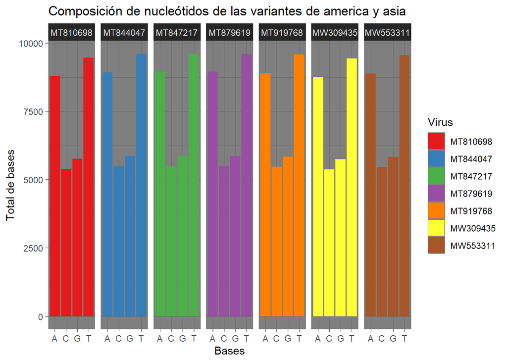

```r
p <- ggplot(datos, aes(x=bases, y=tots, fill=virus)) + geom_bar(stat = "identity") + facet_grid(~virus) + scale_fill_brewer(palette = "Set1") + ggtitle("Composición de nucleótidos de las variantes de america y asia") + labs(x="Bases", y="Total de bases", fill="Virus") + theme_dark()

p
```

```r
#Variantes 8-14
numSecuencias <- 7
numBases <- 4
datos2 <- data.frame( bases=rep(c('A', 'C', 'G', 'T'), times=numSecuencias),
                     virus=c(rep("MT781415", times=numBases),
                     rep("MT372481", times=numBases),
                     rep("MT800035", times=numBases),
                     rep("MT801001", times=numBases),
                     rep("MT801041", times=numBases),
                     rep("LR963411", times=numBases),
                     rep("MW751197", times=numBases)),
                     tots=c(as.vector(table(Var8)), as.vector(table(Var9)),as.vector(table(Var10)),
                     as.vector(table(Var11)),as.vector(table(Var12)),as.vector(table(Var13)),as.vector(table(Var14))))

head(datos2,28)
```

|  | bases | virus | tots |
| --- | --- | --- | --- |
| 1 | A | MT781415 | 8909 |
| 2 | C | MT781415 | 5483 |
| 3 | G | MT781415 | 5853 |
| 4 | T | MT781415 | 9579 |
| 5 | A | MT372481 | 8961 |
| 6 | C | MT372481 | 5485 |
| 7 | G | MT372481 | 5857 |
| 8 | T | MT372481 | 9594 |
| 9 | A | MT800035 | 8894 |
| 10 | C | MT800035 | 5470 |

[output cut: 18 more lines]

```r
str(datos2)
```

```
## 'data.frame':    28 obs. of  3 variables:
##  $ bases: chr  "A" "C" "G" "T" ...
##  $ virus: chr  "MT781415" "MT781415" "MT781415" "MT781415" ...
##  $ tots : int  8909 5483 5853 9579 8961 5485 5857 9594 8894 5470 ...
```

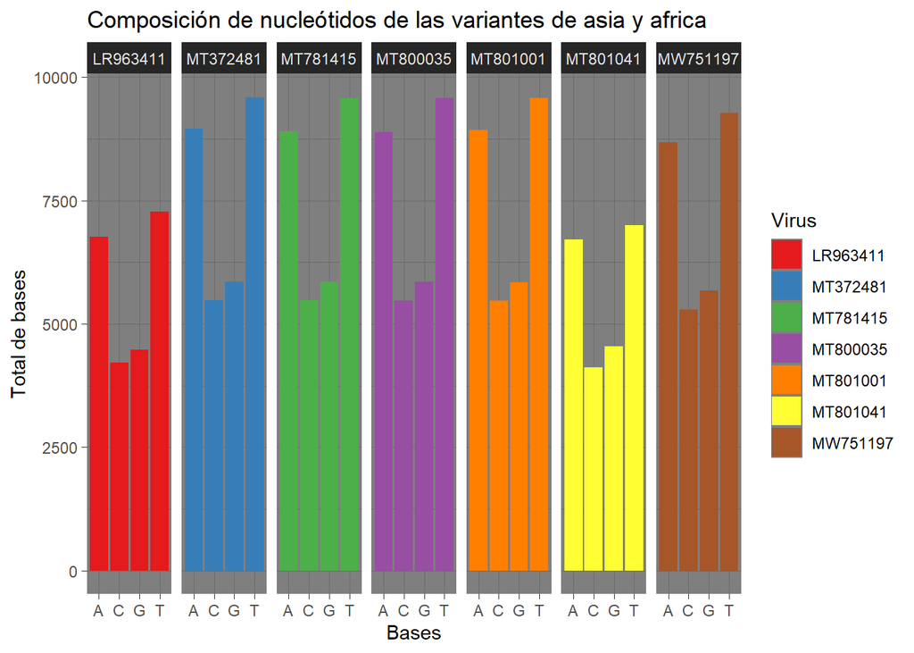

```r
p <- ggplot(datos2, aes(x=bases, y=tots, fill=virus)) + geom_bar(stat = "identity") + facet_grid(~virus) + scale_fill_brewer(palette = "Set1") + ggtitle("Composición de nucleótidos de las variantes de asia y africa") + labs(x="Bases", y="Total de bases", fill="Virus") + theme_dark()

p
```

```r
#Variantes 15-21
numSecuencias <- 7
numBases <- 4
datos3 <- data.frame( bases=rep(c('A', 'C', 'G', 'T'), times=numSecuencias),
                     virus=c(rep("OA975181", times=numBases),
                     rep("OA984027", times=numBases),
                     rep("LR991977", times=numBases),
                     rep("LR883306", times=numBases),
                     rep("MW423684", times=numBases),
                     rep("MT459924", times=numBases),
                     rep("MT973296", times=numBases)),
                     tots=c(as.vector(table(Var15)), as.vector(table(Var16)),as.vector(table(Var17)),
                     as.vector(table(Var18)),as.vector(table(Var19)),as.vector(table(Var20)),as.vector(table(Var21))))

head(datos3,28)
```

|  | bases | virus | tots |
| --- | --- | --- | --- |
| 1 | A | OA975181 | 8743 |
| 2 | C | OA975181 | 5359 |
| 3 | G | OA975181 | 5735 |
| 4 | T | OA975181 | 9411 |
| 5 | A | OA984027 | 8892 |
| 6 | C | OA984027 | 5467 |
| 7 | G | OA984027 | 5845 |
| 8 | T | OA984027 | 9578 |
| 9 | A | LR991977 | 8797 |
| 10 | C | LR991977 | 5400 |

[output cut: 18 more lines]

```r
str(datos3)
```

```
## 'data.frame':    28 obs. of  3 variables:
##  $ bases: chr  "A" "C" "G" "T" ...
##  $ virus: chr  "OA975181" "OA975181" "OA975181" "OA975181" ...
##  $ tots : int  8743 5359 5735 9411 8892 5467 5845 9578 8797 5400 ...
```

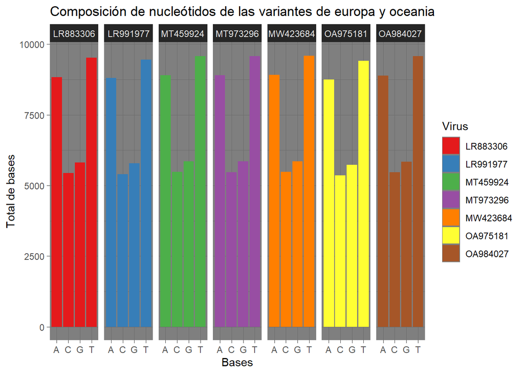

```r
p <- ggplot(datos3, aes(x=bases, y=tots, fill=virus)) + geom_bar(stat = "identity") + facet_grid(~virus) + scale_fill_brewer(palette = "Set1") + ggtitle("Composición de nucleótidos de las variantes de europa y oceania") + labs(x="Bases", y="Total de bases", fill="Virus") + theme_dark()

p
```